# Part II - (Ford Go-Bike System Exploration)

## by (Emna Krichene)

## Investigation Overview

In Ford Go-Bike System data, 74.5% of users are Male, Females represent 23.41% of users, whereas other gender represents 2.08% of data.

90.47% of users are subscribers.

For all investigations, Male take less time.

Users who start their trip in early morning take less time to reach their end station.

Most user ages are around 30 and 40 years old.

## Dataset Overview

> This work explores Ford Go-Bike System Dataset including user type, gender member, duration and starting date. This data set includes information about 183412 rides made in a bike-sharing system covering the greater San Francisco Bay area.

## (Visualization 1) Distribution of ages per gender

We notice in this graph that most ages are between 30 and 40 for all genders, followed by ages between 20 and 30 and ages between 40 and 50 with a slight difference between men and women.

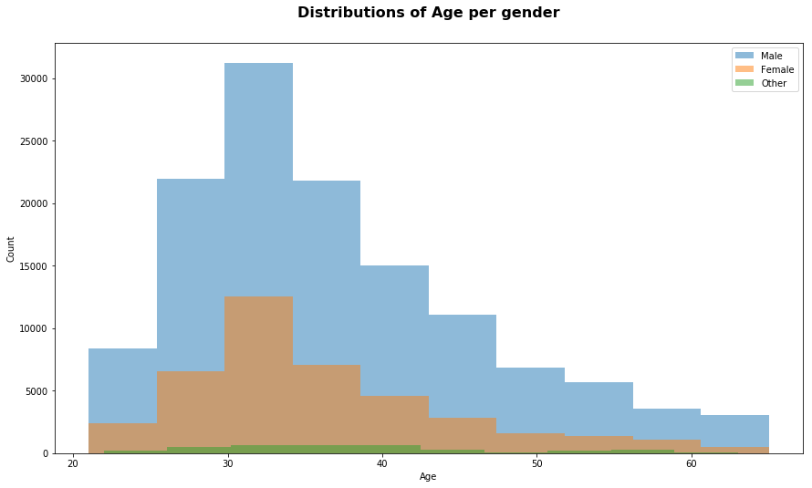

## (Visualization 2) The influence of hour start time on the duration trip

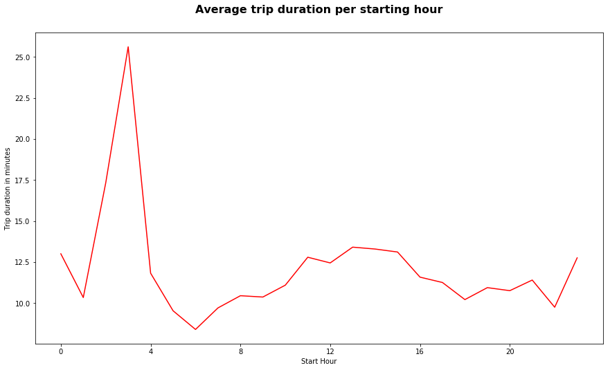

## (Visualization 3) Does the session start time afffect the duration trip?

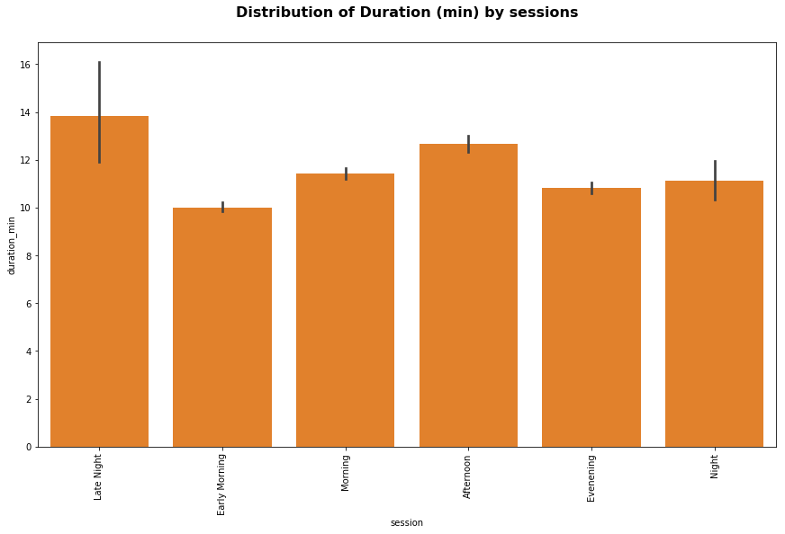